# ML_Hackathon

Gazal

10 November 2017

```r
#rm(list = ls())
library(mice)
library(VIM)
library(plyr)
library(dplyr)
```

```r
library(ggplot2)
library(corrplot)
library(tree)
library(e1071)
library(class)
library(randomForest)
color_v=c("gray37","burlywood3","peachpuff4",
          "chocolate1","darkgoldenrod1","coral2",
          "mediumorchid1","cadetblue")
getmode <- function(v)
{
  uniqv <- unique(v)
  uniqv[which.max(tabulate(match(v, uniqv)))]
}
pMiss <- function(x){sum(is.na(x))/length(x)*100}
```

# Getting Dataset

Data Cleaning Approach: 1) dataset had error(useless replication) in label data which was replaced with accordingly.

2. Missing values in occupation and workclass found co-related and conclusion was replaced for each of the values in factor form
3. nativecountry field had several level which found to have insignificant effect on output with random forest therefore it was removed

```r
file_path = "D:/STUDY/hackathon/ML/Model_Data.csv"
dataset <- read.csv(file_path)

 head(dataset)
```

```
##   age  workclass fnlwgt  education educationnum       maritalstatus
## 1  43    Private 346189    Masters           14  Married-civ-spouse
## 2  25    Private 220931  Bachelors           13       Never-married
## 3  23    Private 134446    HS-grad            9           Separated
## 4  65    Private 136384    Masters           14  Married-civ-spouse
## 5  22    Private  54164    HS-grad            9       Never-married
## 6  34  Local-gov 382078  Bachelors           13  Married-civ-spouse
##           occupation   relationship   race   sex capitalgain capitalloss
## 1    Exec-managerial        Husband  White  Male           0           0
## 2     Prof-specialty  Not-in-family  White  Male           0           0
## 3  Machine-op-inspct      Unmarried  Black  Male           0           0
## 4     Prof-specialty        Husband  White  Male           0           0
## 5      Other-service  Not-in-family  White  Male       14084           0
## 6    Exec-managerial        Husband  White  Male        3103           0
##   hoursperweek  nativecountry COMPENSATION
## 1           50  United-States        >50K.
## 2           43           Peru       <=50K.
## 3           54  United-States       <=50K.
## 4           50  United-States        >50K.
## 5           60  United-States        >50K.
## 6           50  United-States        >50K.
```

```r
# str(dataset)
# summary(dataset)
dataset$COMPENSATION <- as.character(dataset$COMPENSATION)
dataset$COMPENSATION[dataset$COMPENSATION == " <=50K."] = " <=50K"
dataset$COMPENSATION[dataset$COMPENSATION == " >50K."] = " >50K"
dataset$COMPENSATION <- as.factor(dataset$COMPENSATION)
head(dataset$COMPENSATION)
```

```
## [1]  >50K   <=50K  <=50K  >50K   >50K   >50K
## Levels:  <=50K  >50K
```

```r
# dataset %>%
#   filter(occupation != " ?" | age != " ?" | workclass != " ?" | fnlwgt != " ?" | education != " ?" | educationnum != " ?" | maritalstatus != " ?" |   occupation != " ?" |    relationship    != " ?" | race != " ?" |    sex != " ?" |   capitalgain != " ?" |   hoursperweek    != " ?" | COMPENSATION != " ?" ) -> dataset


dataset %>%
  mutate(occupation = ifelse(occupation == " ?", " None", occupation),
         workclass = ifelse(dataset$workclass ==  " ?"," Never-worked", workclass)) %>%
  mutate(occupation = as.factor(occupation),
         workclass = as.factor(workclass) )-> dataset
drops = c("nativecountry")
dataset[ , !(names(dataset) %in% drops)] -> dataset
```

# data spliting -

random sampling in 80 x 20 ratio

```r
# step 6: train and test data

  data_size <- nrow(dataset)
  smp_size <- floor(0.8 * data_size)

  # set the seed to make your partition reproductible

  set.seed(07)
  train_index <- sample(seq_len(data_size), size = smp_size)

  train <- dataset[train_index, ]
  test <- dataset[-train_index, ]
```

# data preparation

```r
#str(train)
#nrow(train)

drops = c("nativecountry")
train[ , !(names(train) %in% drops)] -> train_sub

str(train_sub)
```

```
## 'data.frame':    30718 obs. of  14 variables:
##  $ age          : int  47 17 74 24 17 26 22 38 18 36 ...
##  $ workclass    : Factor w/ 9 levels " Never-worked",..: 5 5 5 1 5 5 5 7 1 5 ...
##  $ fnlwgt       : int  358382 121037 146365 35633 146329 265781 440934 423616 326640 163290 ...
##  $ education    : Factor w/ 16 levels " 10th"," 11th",..: 12 3 12 16 3 10 16 12 12 16 ...
##  $ educationnum : int  9 8 9 10 8 13 10 9 9 10 ...
##  $ maritalstatus: Factor w/ 7 levels " Divorced"," Married-AF-spouse",..: 5 5 7 5 5 5 5 3 5 1 ...
##  $ occupation   : Factor w/ 15 levels " None","10","11",..: 15 5 15 1 5 11 5 5 1 5 ...
##  $ relationship : Factor w/ 6 levels " Husband"," Not-in-family",..: 2 4 2 2 4 2 5 6 4 5 ...
##  $ race         : Factor w/ 5 levels " Amer-Indian-Eskimo",..: 3 5 5 5 5 5 5 5 5 5 ...
##  $ sex          : Factor w/ 2 levels " Female"," Male": 2 1 1 2 1 2 2 1 1 1 ...
##  $ capitalgain  : int  0 0 0 0 0 0 0 0 0 0 ...
##  $ capitalloss  : int  0 0 0 0 0 0 0 0 0 0 ...
##  $ hoursperweek : int  40 15 28 40 23 60 40 24 20 40 ...
##  $ COMPENSATION : Factor w/ 2 levels " <=50K"," >50K": 1 1 1 1 1 1 1 2 1 1 ...
```

```r
nrow(train_sub)
```

```
## [1] 30718
```

```r
# ggplot(train_sub, aes(x=education,
#                     y=education.num,
#                     color=education)) +
#   geom_jitter()

 #randomforest.model = randomForest(COMPENSATION ~ . , data = train_sub)

 #randomforest.model$Importance -> imp_var

 #varImpPlot(randomforest.model)
```

# plots :

```r
# # dataset of continuous variables of data
# int_df <- Filter(is.numeric, train_sub)
# #print(head(int_df))
#
# #int_df <- int_df[c(-1,-2)]
#
# # continuous variable colnames
# sdf_cols_int <- colnames(int_df)
#
# print(sdf_cols_int)
#
# for(i in 1:ncol(int_df))
# {
#   # remove null from column
#   column_name = sdf_cols_int[i]
#   cat("\n\n column : ",column_name)
#
#   column_int_df = int_df[i]
#   column_int_df = column_int_df[!apply(is.na(column_int_df) |
#                                              column_int_df == "", 1, all),]
#
#   # count of total values
#   total_count_column = nrow(int_df[i])
#
#   # count of null values
#   column_int_df_null_count = total_count_column - length(column_int_df)
#
#   # percentage of null in column
#   column_null_perc = column_int_df_null_count/total_count_column
#   cat("\n null value percentage : ", column_null_perc)
#
#   # range of column
#   column_range = range(column_int_df)
#   cat("\n range : ", column_range)
#
#   # printing quantile of column
#   column_quantile = quantile(column_int_df)
#   cat("\n quantile : ", column_quantile)
#
#   # printing minimum of column
#   column_min = min(column_int_df)
#   cat("\n minimum : ", column_min)
#
#   # printing maximum of column
#   column_max = max(column_int_df)
#   cat("\n maximum : ", column_max)
#
#   # printing mean of column
#   column_mean = mean(column_int_df)
#   cat("\n mean : ", column_mean)
#
#   # printing median of column
#   column_median = median(column_int_df)
#   cat("\n median : ", column_median)
#
#   # printing mode of column using user defined function
#   column_mode = getmode(column_int_df)
#   cat("\n mode : ", column_mode)
#
#   # Median Absolute Deviation
#   column_mad = mad(column_int_df)
#   cat("\n median absolute deviation : ", column_mad)
#
#   # variance
#   column_variance = var(column_int_df)
#   cat("\n variance : ", column_variance)
#
#   # standanrd deviation
#   column_sd = sd(column_int_df)
#   cat("\n standard deviance : ", column_sd)
#
#   # understanding scattered data
#   plot(column_int_df, xlab = column_name, ylab = "Values",
#              col = color_v,
#              main = paste("Scatter Plot for", column_name))
#   # understanding frequency distribution of values
#   hist(column_int_df, xlab = column_name, ylab = "Frequency",
#              col = color_v,
#              main = paste("Histogram for", column_name))
#
#   # undertstanding outliers using boxplot
#   boxplot(column_int_df, xlab = column_name,
#                col=color_v)
# }
#
# head(int_df)
# cor(int_df) -> cor_int_df
# print(cor_int_df)
# corrplot(cor_int_df,
#          method = "color",
#          order = "hclust",
#          addrect = 3)
```

```r
# factor_df <- Filter(is.factor, train_sub)
#
# # removing name and email id as they are not very much useful for analysis
# #factor_df <- factor_df[c(-1,-2)]
#
# # factor variable colnames
# sdf_cols_factor <- colnames(factor_df)
#
# print(sdf_cols_factor)
#
# for(i in 1:length(sdf_cols_factor))
# {
#   column_name = sdf_cols_factor[i]
#   cat("\n\n Factor : ")
#   print(column_name)
#   column_factor_df = as.factor(factor_df[,i])
#
#   # count of total values
#   total_count_column = nrow(factor_df[i])
#
#   cat("\n levels : ")
#   print(levels(column_factor_df))
#
#   cat("\n number of levels : ")
#   print(nlevels(column_factor_df))
#
#   cat("\n Orders? : ")
#   print(is.ordered(column_factor_df))
#
#   mode_fac = getmode(column_factor_df)
#   cat("\n Mode : ")
#   print(mode_fac)
#
#   count_fac = count(column_factor_df)
#   print(count_fac)
#
#   # understanding frequency
#   barplot(prop.table(table(column_factor_df)))
#
#   # understanding relative frequency of values
#
#   labels <- count_fac$x
#   x <- count_fac$freq
#
#   pie(x, labels, main = column_name, col = rainbow(length(x)))
#
# }
```

```r
#   pMiss <- function(x){sum(is.na(x))/length(x)*100}
#   apply(train_sub,2,pMiss)
#
# data_pattern = md.pattern(train_sub)
#
# print(train_sub)
#
# imputation_plot = aggr(train_sub,
#                        col = color_v,
#                        numbers = TRUE,
#                        sortVars = FALSE,
#                        labels = names(train_sub),
#                        cex.axis = 0.9,
#                        gap = 2,
#                        ylabs = c("Missing Data","Pattern"))
# print(imputation_plot)
```

# model 1 - Decision Tree

```r
  tree.model = tree(COMPENSATION ~ . , data = train_sub)

# step 8: view model

  # model text and summary
  print(tree.model)
```

```
## node), split, n, deviance, yval, (yprob)
##       * denotes terminal node
##
##  1) root 30718 33920.0  <=50K ( 0.75910 0.24090 )
##    2) relationship:  Not-in-family, Other-relative, Own-child, Unmarried 16791  8080.0  <=50K ( 0.93497 0.06503 )
##      4) capitalgain < 7055.5 16502  6510.0  <=50K ( 0.95043 0.04957 )
##        8) education:  10th, 11th, 12th, 1st-4th, 5th-6th, 7th-8th, 9th, Assoc-acdm, Assoc-voc, HS-grad, Preschool, Some-college 13234  3066.0  <=50K ( 0.97529 0.02471 ) *
##        9) education:  Bachelors, Doctorate, Masters, Prof-school 3268  2766.0  <=50K ( 0.84976 0.15024 ) *
##      5) capitalgain > 7055.5 289   118.0  >50K ( 0.05190 0.94810 ) *
##    3) relationship:  Husband, Wife 13927 19180.0  <=50K ( 0.54707 0.45293 )
##      6) education:  10th, 11th, 12th, 1st-4th, 5th-6th, 7th-8th, 9th, Assoc-acdm, Assoc-voc, HS-grad, Preschool, Some-college 9663 12290.0  <=50K ( 0.66739 0.33261 )
##       12) capitalgain < 5095.5 9166 11160.0  <=50K ( 0.70238 0.29762 )
##         24) occupation:  None,10,15,4,6,7,8,9 5632  5897.0  <=50K ( 0.78267 0.21733 ) *
##         25) occupation: 11,12,13,14,2,3,5 3534  4821.0  <=50K ( 0.57442 0.42558 ) *
##       13) capitalgain > 5095.5 497   105.6  >50K ( 0.02213 0.97787 ) *
##      7) education:  Bachelors, Doctorate, Masters, Prof-school 4264  5011.0  >50K ( 0.27439 0.72561 )
##       14) capitalgain < 5095.5 3622  4557.0  >50K ( 0.32303 0.67697 ) *
##       15) capitalgain > 5095.5 642     0.0  >50K ( 0.00000 1.00000 ) *
```

```r
  print(summary(tree.model))
```

```
##
## Classification tree:
## tree(formula = COMPENSATION ~ ., data = train_sub)
## Variables actually used in tree construction:
## [1] "relationship" "capitalgain"  "education"    "occupation"
## Number of terminal nodes:  8
## Residual mean deviance:  0.6946 = 21330 / 30710
## Misclassification error rate: 0.1544 = 4742 / 30718
```

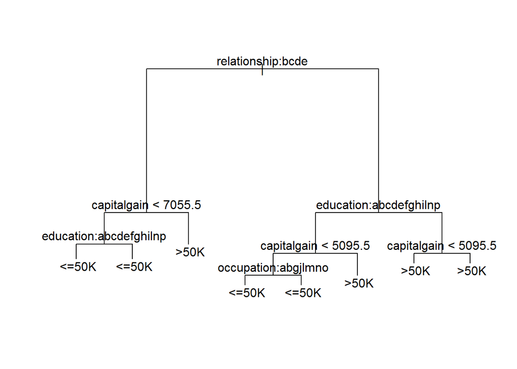

```r
  # plot model
  plot(tree.model)
  text(tree.model)
```

```r
  #library(rpart.plot)
  #prp(tree.model, extra=7, prefix="fraction\n")

# step 9: predict for test data

  #Predict Output

  model_prediction = predict(tree.model,test)

  maxidx = function(arr)
  {
    return(which(arr == max(arr)))
  }

  idx = apply(model_prediction, c(1), maxidx)

  predicted = c('No','Yes')[idx]
  confmat =  table(predicted, test$COMPENSATION)

  print(confmat)
```

```
##
## predicted  <=50K  >50K
##       No    5582   920
##       Yes    272   906
```

```r
  # step 10: check accuracy
  model_accuracy = sum(diag(confmat))/sum(confmat)

  print(model_accuracy)
```

```
## [1] 0.8447917
```

# Decision Tree accuracy

```r
cat("\n",model_accuracy)
```

```
##
##  0.8447917
```

# model 2 - Naive bayes

```r
  naiveBayesModel <- naiveBayes(COMPENSATION ~ .,
                                 data = train_sub)

  print(naiveBayesModel)
```

```
##
## Naive Bayes Classifier for Discrete Predictors
##
## Call:
## naiveBayes.default(x = X, y = Y, laplace = laplace)
##
## A-priori probabilities:
## Y
##     <=50K      >50K
## 0.7590989 0.2409011
##
## Conditional probabilities:
##         age
## Y            [,1]     [,2]
##    <=50K 36.88009 14.09913
##    >50K  44.21541 10.49540
##
##         workclass
## Y         Never-worked            2            3            4            5
##    <=50K  0.0671155331 0.0238013552 0.0605969637 0.0003859679 0.7133544901
##    >50K   0.0202702703 0.0509459459 0.0797297297 0.0000000000 0.6317567568
##         workclass
## Y                   6            7            8            9
##    <=50K 0.0207993825 0.0750493181 0.0384252509 0.0004717386
##    >50K  0.0787837838 0.0935135135 0.0448648649 0.0001351351
##
##         fnlwgt
## Y            [,1]     [,2]
##    <=50K 190026.7 106535.0
##    >50K  189860.7 102928.7
##
##         education
## Y                10th         11th         12th      1st-4th      5th-6th
##    <=50K 0.0362809846 0.0454584441 0.0171541299 0.0064327987 0.0132515653
##    >50K  0.0081081081 0.0068918919 0.0043243243 0.0005405405 0.0024324324
##         education
## Y             7th-8th          9th   Assoc-acdm    Assoc-voc    Bachelors
##    <=50K 0.0240586671 0.0190410841 0.0321639935 0.0412985676 0.1280555794
##    >50K  0.0060810811 0.0033783784 0.0322972973 0.0450000000 0.2891891892
##         education
```

[output cut: 57 more lines]

```
##
##         capitalgain
## Y             [,1]       [,2]
##    <=50K  149.7479   966.9373
##    >50K  4020.8478 14654.0744
##
##         capitalloss
## Y             [,1]     [,2]
##    <=50K  53.31053 309.7082
##    >50K  191.97973 591.3406
##
##         hoursperweek
## Y            [,1]     [,2]
##    <=50K 38.82769 12.40530
##    >50K  45.56446 11.29042
```

```r
  prediction = predict(naiveBayesModel,
                         test[,-1])

  #print(prediction)
  confmat = table(prediction,test$COMPENSATION)

  #print(confmat)

  accuracy = sum(diag(confmat)) / sum(confmat)

  print(accuracy)
```

```
## [1] 0.8248698
```

# Naive Baye accuracy

```r
cat("\n",accuracy)
```

```
##
##  0.8248698
```

```r
file_path = "D:/STUDY/hackathon/ML/Assignment\ -\ 3 update/Model_Data.csv"
 dataset <- read.csv(file_path)

  head(dataset)
```

```
##   age  workclass fnlwgt  education educationnum       maritalstatus
## 1  43    Private 346189    Masters           14  Married-civ-spouse
## 2  25    Private 220931  Bachelors           13       Never-married
## 3  23    Private 134446    HS-grad            9           Separated
## 4  65    Private 136384    Masters           14  Married-civ-spouse
## 5  22    Private  54164    HS-grad            9       Never-married
## 6  34  Local-gov 382078  Bachelors           13  Married-civ-spouse
##           occupation   relationship   race   sex capitalgain capitalloss
## 1    Exec-managerial        Husband  White  Male           0           0
## 2     Prof-specialty  Not-in-family  White  Male           0           0
## 3  Machine-op-inspct      Unmarried  Black  Male           0           0
## 4     Prof-specialty        Husband  White  Male           0           0
## 5      Other-service  Not-in-family  White  Male       14084           0
## 6    Exec-managerial        Husband  White  Male        3103           0
##   hoursperweek  nativecountry COMPENSATION
## 1           50  United-States        >50K.
## 2           43           Peru       <=50K.
## 3           54  United-States       <=50K.
## 4           50  United-States        >50K.
## 5           60  United-States        >50K.
## 6           50  United-States        >50K.
```

```r
 # str(dataset)
 # summary(dataset)
 dataset$COMPENSATION <- as.character(dataset$COMPENSATION)
 dataset$COMPENSATION[dataset$COMPENSATION == " <=50K."] = " <=50K"
 dataset$COMPENSATION[dataset$COMPENSATION == " >50K."] = " >50K"
 dataset$COMPENSATION <- as.factor(dataset$COMPENSATION)
 head(dataset$COMPENSATION)
```

```
## [1]  >50K   <=50K  <=50K  >50K   >50K   >50K
## Levels:  <=50K  >50K
```

```r
 dataset %>%
   mutate(occupation = ifelse(occupation == " ?", " None", occupation),
          workclass = ifelse(dataset$workclass ==  " ?"," Never-worked", workclass)) %>%
   mutate(occupation = as.factor(occupation),
          workclass = as.factor(workclass) )-> dataset


 drops = c("nativecountry")
 dataset[ , !(names(dataset) %in% drops)] -> dataset


   data_size <- nrow(dataset)
   smp_size <- floor(0.8 * data_size)

   # set the seed to make your partition reproductible

   set.seed(07)
   train_index <- sample(seq_len(data_size), size = smp_size)

     train <- dataset[train_index, ]
   test <- dataset[-train_index, ]

  test[ , !(names(test) %in% drops)] -> test_sub
   train[ , !(names(train) %in% drops)] -> train_sub
```

# model 3 kNN

```r
#head(train_sub)

#fact_df <- fact_df[,-c(ncol(fact_df))]
for(i in 1:(ncol(train_sub)-1))
{
  if(is.factor(train_sub[,i]))
  {
    train_sub[,i] <- as.numeric(train_sub[,i])
    test_sub[,i] <- as.numeric(test_sub[,i])
  }
}
#
# for(i in 1:(ncol(test)-1))
# {
#   if(is.factor(test[,i]))
#   {
#     test[,i] <- as.numeric(test[,i])
#   }
# }

train_independent =  Filter(is.numeric, train_sub)
ncol(train_sub) -> n
train_dependent = train_sub[,n]

test_independent <-  Filter(is.numeric, test_sub)

test_dependent = test[,n]

#null value percentage
apply(train_independent,2,pMiss)
```

```
##           age     workclass        fnlwgt     education  educationnum
##             0             0             0             0             0
## maritalstatus    occupation  relationship          race           sex
##             0             0             0             0             0
##   capitalgain   capitalloss  hoursperweek
##             0             0             0
```

```r
# choose value for number of nearest neighbor k

#k= 5

for(i in seq(1,20,by=1))
{
  k = i
 knn(train_independent,
     test = test_independent,
     cl = train_dependent,
     k) -> knn_model_predicted_labels

  confmat = table(test_dependent,knn_model_predicted_labels)

  #print(confmat)

  accuracy[k] = sum(diag(confmat)) / sum(confmat)
  cat("\naccuracy at",k, " is ",accuracy[k])
}
```

```
##
## accuracy at 1  is  0.7367187
## accuracy at 2  is  0.7244792
## accuracy at 3  is  0.7661458
## accuracy at 4  is  0.7596354
## accuracy at 5  is  0.7755208
## accuracy at 6  is  0.7731771
## accuracy at 7  is  0.7873698
## accuracy at 8  is  0.7855469
## accuracy at 9  is  0.789974
## accuracy at 10  is  0.7895833
## accuracy at 11  is  0.7942708
## accuracy at 12  is  0.7953125
## accuracy at 13  is  0.8001302
## accuracy at 14  is  0.7992187
## accuracy at 15  is  0.8011719
## accuracy at 16  is  0.8023438
## accuracy at 17  is  0.8018229
## accuracy at 18  is  0.8028646
## accuracy at 19  is  0.8027344
## accuracy at 20  is  0.803125
```

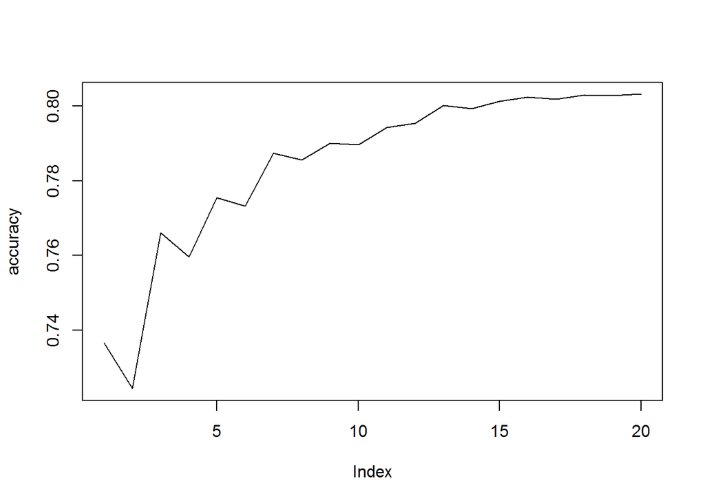

```r
  plot(accuracy, type ="l")
```

```r
  correlationMatrix <- cor(train_independent)
# summarize the correlation matrix

  print(correlationMatrix)
```

```
##                       age   workclass        fnlwgt   education
## age            1.00000000  0.01883784 -0.0740835967 -0.01266553
## workclass      0.01883784  1.00000000 -0.0200426798  0.01699057
## fnlwgt        -0.07408360 -0.02004268  1.0000000000 -0.01670363
## education     -0.01266553  0.01699057 -0.0167036339  1.00000000
## educationnum   0.03159358  0.05528187 -0.0381656559  0.36139611
## maritalstatus -0.26702364 -0.06298378  0.0293241214 -0.04215017
## occupation    -0.06859872  0.29709055  0.0006714148 -0.07888259
## relationship  -0.25660762 -0.08956236  0.0080794723 -0.01572295
## race           0.02831051  0.04345557 -0.0327886179  0.01210192
## sex            0.08472175  0.08686666  0.0241709571 -0.02006141
## capitalgain    0.08010149  0.03474571 -0.0008515508  0.02808789
## capitalloss    0.05495382  0.01132681 -0.0060938082  0.02033600
## hoursperweek   0.07183097  0.14405289 -0.0157872756  0.05391380
##               educationnum maritalstatus    occupation relationship
## age             0.03159358  -0.267023644 -0.0685987222 -0.256607623
## workclass       0.05528187  -0.062983780  0.2970905512 -0.089562360
## fnlwgt         -0.03816566   0.029324121  0.0006714148  0.008079472
## education       0.36139611  -0.042150169 -0.0788825917 -0.015722953
## educationnum    1.00000000  -0.069647161 -0.2947808893 -0.090397744
## maritalstatus  -0.06964716   1.000000000  0.0083850071  0.183534830
## occupation     -0.29478089   0.008385007  1.0000000000  0.014571138
## relationship   -0.09039774   0.183534830  0.0145711377  1.000000000
## race            0.02978945  -0.073598838 -0.0323948591 -0.120671485
## sex             0.01086529  -0.121370201  0.0539823490 -0.586267065
## capitalgain     0.12101681  -0.044059202 -0.0462798953 -0.053498653
## capitalloss     0.07981521  -0.036463049 -0.0364073516 -0.057618943
## hoursperweek    0.14538584  -0.185997180  0.0113257508 -0.251974519
##                      race         sex   capitalgain  capitalloss
## age            0.02831051  0.08472175  0.0801014898  0.054953818
## workclass      0.04345557  0.08686666  0.0347457092  0.011326812
## fnlwgt        -0.03278862  0.02417096 -0.0008515508 -0.006093808
## education      0.01210192 -0.02006141  0.0280878910  0.020335996
## educationnum   0.02978945  0.01086529  0.1210168098  0.079815206
## maritalstatus -0.07359884 -0.12137020 -0.0440592015 -0.036463049
## occupation    -0.03239486  0.05398235 -0.0462798953 -0.036407352
## relationship  -0.12067149 -0.58626707 -0.0534986529 -0.057618943
## race           1.00000000  0.08941771  0.0149882576  0.017414573
## sex            0.08941771  1.00000000  0.0457179818  0.045460844
## capitalgain    0.01498826  0.04571798  1.0000000000 -0.031533215
## capitalloss    0.01741457  0.04546084 -0.0315332148  1.000000000
## hoursperweek   0.04354823  0.23145164  0.0762435127  0.055894751
##               hoursperweek
## age             0.07183097
## workclass       0.14405289
## fnlwgt         -0.01578728
## education       0.05391380
## educationnum    0.14538584
## maritalstatus  -0.18599718
## occupation      0.01132575
## relationship   -0.25197452
## race            0.04354823
## sex             0.23145164
## capitalgain     0.07624351
## capitalloss     0.05589475
## hoursperweek    1.00000000
```

```r
# corrplot(correlationMatrix,
#          method = "color",
#          order = "hclust",
#          addrect = 4)
```

# knn accuracy

```r
cat("\n",accuracy[16])
```

```
##
##  0.8023438
```

```r
# randomforest.model = randomForest(COMPENSATION ~ . , data = train_sub)
#
# randomforest.model$Importance -> imp_var
#
# varImpPlot(randomforest.model)
```

# Generalization :

Generalization is a term used to describe a model’s ability to react to new data. That is, after being trained on a training set, a model can digest new data and make accurate predictions. A model’s ability to generalize is central to the success of a model.

If a model has been trained too well on training data, it will be unable to generalize. It will make inaccurate predictions when given new data, making the model useless even though it is able to make accurate predictions for the training data. This is called overfitting. In this problem statement, getting more than 90% accuracy on test data would be clearly overfitting

Underfitting happens when a model has not been trained enough on the data. In the case of underfitting, it makes the model just as useless and it is not capable of making accurate predictions, even with the training data.

Therefore, the model needs to note a trend in the data, in a way that it doesn’t become too specific and it can nearly predict the coming new data.